# Simple Chart Type Examples

Anamaria Crisan

2019-01-08

This document demonstrates how to implement and plot different chart types using gevitR. This document assumes that you have already run the “Getting started with gevitR” and that the necessary data as already been loaded into your R workspace.

```r
devtools::load_all() #temporary once things are done
library(dplyr)

#Table data
tab_dat<-input_data(file = system.file("extdata", "ebov_metadata.csv", package = "gevitR"),dataType = "table")

#Tree data
tree_dat<-input_data(file = system.file("extdata", "ebov_tree.nwk", package = "gevitR"),dataType = "tree")

#Genomic data
genomic_dat<-input_data(file = system.file("extdata", "ebov_GIN_genomic.fasta", package = "gevitR"),dataType = "dna")

#Shape files
#Shape files require that .shp,.shx,and .prj files at a minimun to be in the same directory
#to add metadata to the shape file, you can also add .dbf files
gin_shape_dat<-input_data(file = system.file("extdata", "gin_admbnda_adm1_ocha_itos.shp", package = "gevitR"),dataType = "spatial")
lbr_shape_dat<-input_data(file = system.file("extdata", "lbr_admbnda_adm1_ocha.shp", package = "gevitR"),dataType = "spatial")
sle_shape_dat<-input_data(file = system.file("extdata", "sle_admbnda_adm1_1m_gov_ocha_20161017.shp", package = "gevitR"),dataType = "spatial")
```

## Common statistical charts

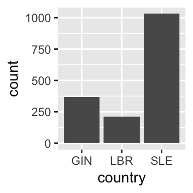

```r
#
# "swarmplot" => implemented specs for this

#a bar chart of all the countries invovled in the ebola outbreak
bar_chart<-specify_base(chart_type = "bar",data="tab_dat",x = "country")
plot(bar_chart)
```

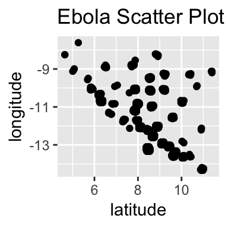

```r
scatter_chart<-specify_base(chart_type = "scatter",data="tab_dat",x = "latitude",y="longitude",title = "Ebola Scatter Plot")
plot(scatter_chart)
```

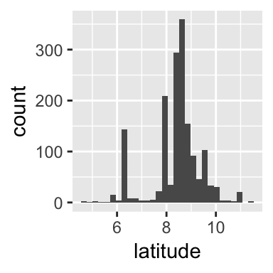

```r
histogram_chart<-specify_base(chart_type = "histogram",data="tab_dat",x = "latitude")
plot(histogram_chart)
```

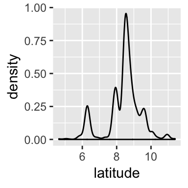

```r
pdf_chart<-specify_base(chart_type = "pdf",data="tab_dat",x = "latitude")
plot(pdf_chart)
```

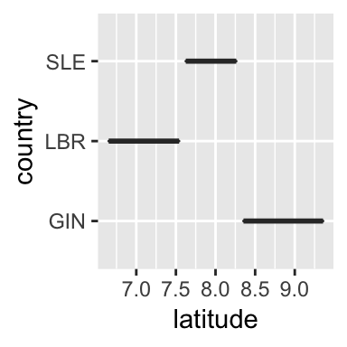

```r
#works but weird a bit
boxplot_chart<-specify_base(chart_type = "boxplot",data="tab_dat",x = "latitude",y="country")
plot(boxplot_chart)
```

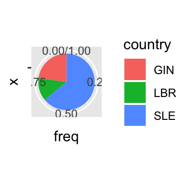

```r
#we'll even let you make a pie chart
pie_chart<-specify_base(chart_type = "pie",data="tab_dat",x = "country")
plot(pie_chart)
```

gevitR can also work with data frames too, so you can perform some analyses and go ahead and plot the data. Here’s an example using a line chart :

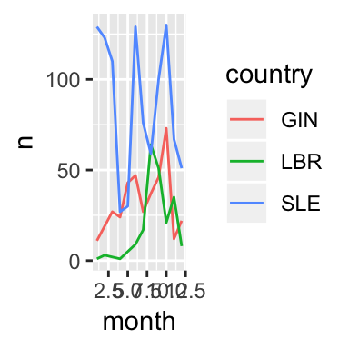

```r
#lets use our tabular data
ebov<-tab_dat@data[[1]] #make this nicer
ebov_case_counts<-ebov %>%
  group_by(country,month) %>%
  count()

line_chart<-specify_base(chart_type = "line",data="ebov_case_counts",x = "month",y="n",group = "country")
plot(line_chart)
```

## Colour charts

Colour charts are common statistical charts those that fundamentally require colour to communicate communicate their results. By comparsion, adding colour to a common statistical chart can be seen as an enhancements (a nice to have, not a need to have).

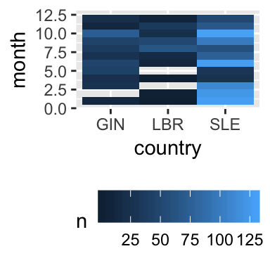

```r
# "category stripe" = do.call(render_category_stripe,args = spec_list),

ebov<-tab_dat@data[[1]] #make this nicer
ebov_heat_data<-ebov %>%
  group_by(country,month) %>%
  count()

heatmap_chart<-specify_base(chart_type = "heatmap",data="ebov_heat_data",x = "country",y="month",z = "n")
plot(heatmap_chart)
```

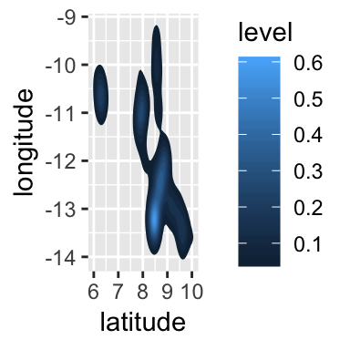

```r
density_chart<-specify_base(chart_type = "density",data="tab_dat",x = "latitude",y="longitude")
plot(density_chart)
```

Category stripes are not really meant to be stand alone chart types, they are generally meant to be enhancements, typically for phylogenetic trees, where adding a category stripe is a common paradigm. But it’s possible to generate a category stripe on its own.

```r
#this doesn't quite work when there are a lot of labels
#maybe the answer here is just a 1D tile plot..
cat_stripe_chart<-specify_base(chart_type = "category stripe",data="tab_dat",x = "site.id",y="bob",category="country")
plot(cat_stripe_chart)
```

[output not shown]

## Spatial charts

```r
map_chart<-specify_base("geographic map",data="tab_dat",lat = "latitude",long = "longitude")
plot(map_chart)
```

[interactive chart not shown]

## Tree charts

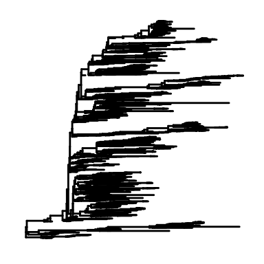

```r
phyloTree_chart<-specify_base(chart_type = "phylogenetic tree",data="tree_dat")
plot(phyloTree_chart)
```

## Images

Sometimes it is desireable to use image data, these can be from interior maps or from gel images. Getting image data to work is a little bit more invovled because it requires there be some annotation data that allows you to link pixel space to something useful. There’s a small application embedded withing this package that lets you do that.

Here’s a workflow with a few different types of images

```r
interior_img<-input_data(file = system.file("extdata", "random_interior_map.tiff", package = "gevitR"),dataType = "image")
```

It’s still possible to simply draw a plot that has no metadata

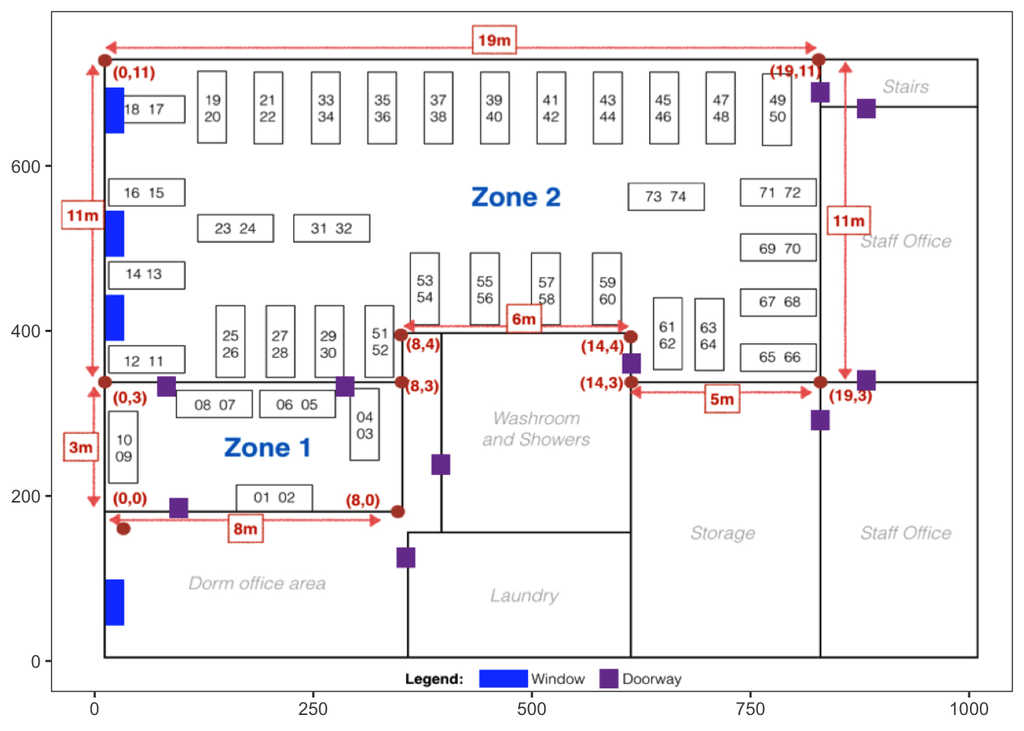

```r
img_chart<-specify_base(chart_type="image",data="interior_img")
plot(img_chart)
```

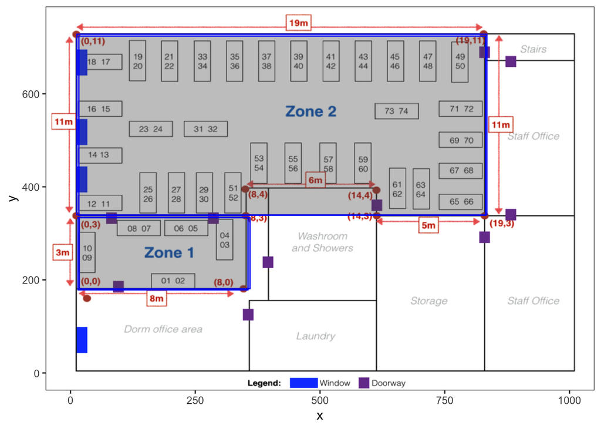

```r
#We'll load an already annotated image to keep things going
#Normally, the user doesn't do this, but we have to do so because
#the previous line of code was not run in the markdown notebook
load(file = system.file("extdata", "img_meta.rds", package = "gevitR"))
interior_img@data$metadata<-metadata

#let's state the spec of the interior map
img_chart<-specify_base(chart_type="image",data="interior_img")
plot(img_chart)
```

Now, let’s do something more interesting, let’s colour these regions

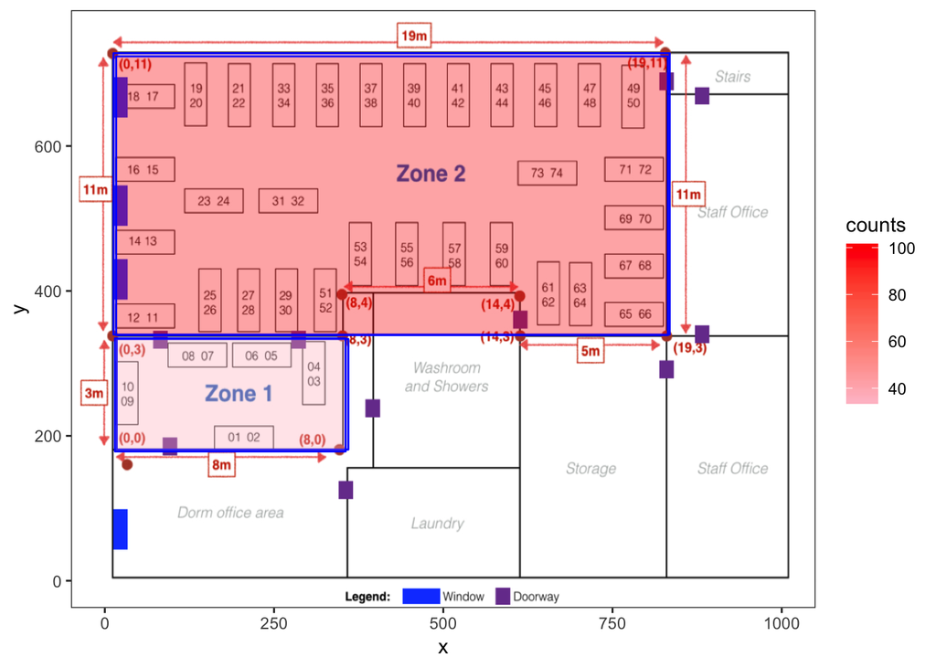

```r
#Finally, lets add some arbitrary case counts to the room
interior_img@data$metadata$counts<-c(100,35)

#let's state the spec of the interior map
img_chart<-specify_base(chart_type="image",data="interior_img",color = "counts")
plot(img_chart)
```